# Control Flow & Functions

## Why this matters?

Most real programs are: decisions + repetition + reusable building blocks.

This file focuses on:

- Decisions: `if/elif/else`, `match/case` (and *why* `match/case` can be clearer than long `if/elif` chains)
- Repetition: `for/while`, `break/continue`, `enumerate`, `zip` (tuple-unpacking)
- Reuse: functions (parameters, defaults, docstrings, type hints, multiple returns)

## Notes for learners

- `elif` must immediately follow the `if` it belongs to (only comments/blank lines may be in between).
- Truthiness: `0`, `0.0`, `''`, `[]`, `{}` are `False`; non-zero numbers and non-empty containers are `True`. Try: `print(bool(0), bool(2))` to see it.
- Prefer clarity over cleverness. We'll show both clear and compact patterns when helpful.
- Safety: For `while True` loops, we include a small safeguard counter to avoid accidental infinite loops.
- Python 3.10+ is assumed for `str | None` type hints and `match/case`. On 3.9 use `Optional[str]` and `if/elif`.

### if/elif/else

Syntax:

```
if (condition1):
  do action1         # executed if 'condition1' == True
elif (condition2):
  do action2
...
else:
  do action{N}       # action{N} with condition1, condition2, ..., condition{N-1} all being False
```

```python
test_input = 'Jin'

# `isinstance()` is a function that checks if an input is equal to a type of
# interest (ex. `isinstance([1, 2, 3], list)`       -> True)
#          (    `isinstance({'A': 1, 'B': 2}, dict) -> True)
if isinstance(test_input, str):
  # `isinstance(test_string, str)` is True, so below will run.
  # Again, we see the use of F string here.
  print(f"Input is a string: {test_input}")

# You can have as many `elif`s as you need/want
# If you want the line below to be executed, what would you do?
# Can you change test_input to an integer value instead of 'Jin'? (ex. 8)
elif isinstance(test_input, int):
  print(f"Input is an integer: {test_input}")
# If `test_input = [1, 2, 3]`, printed output will be: "Input is a list: [1, 2, 3]"
elif isinstance(test_input, list):
  print(f"Input is a list: {test_input}")
# Below is not necessary when you don't want to do anything with False
# condition. Try switching `test_input` to a dict and run this 'cell' again.
else:
  print("Eh, input is not a string")
```

```
Input is a string: Jin
```

### if/else in list comprehension

- Binary choice (only consider True cases):  
  `[(action) for x in {iterable} if (condition)]`
- Additional treatment specified:  
  `[(action1) if (condition) else (action2) for x in {iterable}`]

```python
# Only consider True (i.e. non-zero numbers) cases
integers = range(10)
# Odd numbers or even numbers?
odd_or_even = [x for x in integers if x % 2]
```

`%` is a modulo operator in Python (ex. `3 % 2 = 1`).

1. {iterable} is `range(10)`. This means `x` will be 0, 1, 2, ... 9 at each iteration
2. (action) is `x`, which means to *append* `x` to a list.
3. (condition) is `x % 2`. At each iteration, if this is `True`, append `x`.

In **boolean indexing**, 0 is `False`, and any non-zero number is `True` (yes, not only 1, but 2, 3, etc.).

- If `x` is *even*, then `x % 2 == 0 (False)` -> `x` not appended to the list.
- If `x` is *odd*, then `x % 2 == 1 (True)` -> `x` appended to the list.

```python
odd_or_even
```

```
[1, 3, 5, 7, 9]
```

You can include `else` in a (list) comprehension.

```python
# `else` in a list comprehension
odd_or_even2 = ['Odd' if y % 2 else 'Even' for y in integers]
odd_or_even2
```

```
['Even', 'Odd', 'Even', 'Odd', 'Even', 'Odd', 'Even', 'Odd', 'Even', 'Odd']
```

`elif` is not directly used in a list comprehension. Instead, you 'nest' an `if-else` condition inside an `else` condition.

- Typical `if/elif/else` statement:

  ```
  a_list = list()
  for x in {iterable}:
    if (condition1):
      a_list.append(action1)
    elif (condition2):
      a_list.append(action2)
    else:
      a_list.append(action3)
  ```

- List comprehension's case:

  ```
  a_list = [(action1) if (condition1) else (action2) if (condition2) else (action3) for x in {iterable}]
  ```

```python
#@title First ladies again: run to read csv
import pandas as pd
url = 'https://raw.githubusercontent.com/ohspc89/reprorehab2025/students/contents/week3/first_ladies.csv'
first_ladies = pd.read_csv(url)
first_names = first_ladies.First_name.to_list()
last_names = first_ladies.Last_name.to_list()
```

```python
# Showing the DataFrame we're reading
first_ladies.head()
```

|  | First_name | Last_name | Maiden_name | year_start | year_end |
| --- | --- | --- | --- | --- | --- |
| 0 | Martha | Washington | Dandridge Custis | 1789 | 1797.0 |
| 1 | Abigail | Adams | Smith | 1797 | 1801.0 |
| 2 | Martha | Jefferson Randolph | Wayles Skelton | 1801 | 1809.0 |
| 3 | Dolley | Madison | Payne Todd | 1809 | 1817.0 |
| 4 | Elizabeth | Monroe | Kortright | 1817 | 1825.0 |

```python
# First names of the first ladies
first_names[0:5]
```

```
['Martha', 'Abigail', 'Martha', 'Dolley', 'Elizabeth']
```

```python
# What would `a_list` be like?
# 1) Append "MARTHA!" if a value of the iterable: `first_names` is "Martha"
# 2) Append "Dr.Biden" elif a value of the iterable: `first_names` is "Jill"
# 3) Append None if a value of the iterable is neither "Martha" nor "Jill".
a_list = ["MARTHA!" if x == "Martha" else "Dr.Biden"
          if x == "Jill" else None for x in first_names]
# `filter` is a function that can filter elements.
# Here, we're filtering out `None` from `a_list`, just to remove many `None`.
list(filter(None, a_list))
```

```
['MARTHA!', 'MARTHA!', 'Dr.Biden']
```

### match/case

This is a new feature in Python >=3.10 - useful when your are interested in matching patterns.

```python
test_list = list()
for name in first_names:
  match name:
    case "Martha":
      test_list.append("MARTHA!")
    case "Jill":
      test_list.append("Dr.Biden")
    # Similar to if-elif-else, you can skip 'else' condition
    # you can use '_' - this is similar to `else`
    case _:
      continue  # move on

test_list
```

```
['MARTHA!', 'MARTHA!', 'Dr.Biden']
```

## Loops (for/while)

By now who have seen many `for` loops. The idea is simple, and here I'd like to *revisit* (sorry that I've used these methods already earlier without much explanation) methods that can go well with a `for` loop.

- `enumerate()`: adds a counter
- `zip()`: takes multiple {iterables} and aggregates their elements to a tuple.

```python
# enumerate - if you need a counter
for i, col in enumerate(first_ladies.columns):
  print(f"Column {i+1}: {col}")
```

```
Column 1: First_name
Column 2: Last_name
Column 3: Maiden_name
Column 4: year_start
Column 5: year_end
```

```python
for j, row in enumerate(first_ladies.values):
  # Boolean indexing (0: False, non-zero: True)
  # `not` reverses the boolean value, so `not 0 (False)` is `True`.
  # Therefore, we're only considering values of j that satisfiy `j % 10 == 0`,
  # except `j != 0` (not equal to).
  if (not j % 10) and (j != 0):
    # We're still using `first_ladies`, so printed row content will be:
    # 'fist name', 'last name', 'maiden name', 'year_start', 'year_end'
    print(f"row {j}: {row}")
```

```
row 10: ['Julia' 'Tyler' 'Gardiner' 1844 1845.0]
row 20: ['Lucretia' 'Garfield' 'Rudolph' 1881 1881.0]
row 30: ['Grace' 'Coolidge' 'Goodhue' 1923 1929.0]
row 40: ['Nancy' 'Reagan' 'Davis' 1981 1989.0]
```

```python
# zip(A, B, ...)
# At each iteration, elements of `first_names` and `last_names` will be
# aggregated into a tuple (ex. ('Martha', 'Waghington'))
for i, full_name in enumerate(zip(first_names, last_names)):
  print(f"First name: {full_name[0]}; last name: {full_name[1]}")
  # Just print first 5 full names
  if i >= 5:
    break
```

```
First name: Martha; last name: Washington
First name: Abigail; last name: Adams
First name: Martha; last name: Jefferson Randolph
First name: Dolley; last name: Madison
First name: Elizabeth; last name: Monroe
First name: Louisa; last name: Adams
```

### break/continue

`break` will break the loop. `continue` is to move to the next iteration without any action performed.

```python
# break a loop in the middle
# `first_names` has 48 elements, so `i` can iterate over range(48)
for i, name in enumerate(first_names):
  if name == "Nancy":
    print(f"Nancy found! Closing the loop at the iteration: {i}")
    # iteration terminates when `name == "Nancy"`
    break
  else:
    # If `name == "Nancy"` is False, do nothing and move to the next iteration.
    continue
```

```
Nancy found! Closing the loop at the iteration: 40
```

### Use `while` when you don't know the number of iterations needed.

`for` loops will end when it reaches the last iteration index. If you need to loop while a condition is `True`, use `while`.

```python
# Let's suppose you don't know the index of the first name "Lucretia" in the list: `first_names`

to_lookfor = 'Lucretia'
i = 0   # A start index is typically set to 0 - the starting index
while first_names[i] != to_lookfor:
  i += 1    # `i += 1` is the shorthand of `i = i + 1`

# Remember, Python starts counting from 0, not 1
print(f"{to_lookfor} is the {i+1}th first name")
```

```
Lucretia is the 21th first name
```

```python
# While loop can be "broken" as well

k = 0
counter = 0
# Don't do this - it can lead to an infite loop...
while True:
  if first_names[k] == "Martha":
    counter += 1
  # If "Martha" is found twice, break the loop
  if counter == 2:
    break
  k += 1

print(f"The second 'Martha' is found in row: {k}")
```

```
The second 'Martha' is found in row: 2
```

You may want to provide a safe guard to avoid infinite loops if your code is not correctly written.

```
max_iter = 1000  # limit the number of iterations
steps = 0

while True:
    ...  # whatever action you want to loop over
    steps += 1  # increase the counter
    # if the loop iterates over `max_iter` times,
    # it will raise an error:
    if steps > max_iter:
        raise RuntimeError("Possible infinite loop-check your logic.")
```

If you have convoluted / nested logics, use **for** loops. Whenever possible, however, use **comprehensions** or even **vectorized** methods provided by *numpy* or *pandas*.

Your code may look *longer*, but it will be *faster* if your data is BIG.

```python
# Every 10th rows?
first_ladies.iloc[[x for x in range(10, len(first_ladies), 10)], :]
```

|  | First_name | Last_name | Maiden_name | year_start | year_end |
| --- | --- | --- | --- | --- | --- |
| 10 | Julia | Tyler | Gardiner | 1844 | 1845.0 |
| 20 | Lucretia | Garfield | Rudolph | 1881 | 1881.0 |
| 30 | Grace | Coolidge | Goodhue | 1923 | 1929.0 |
| 40 | Nancy | Reagan | Davis | 1981 | 1989.0 |

```python
# Lucretia, 20th first name
# Remember `.str.match()`?
first_ladies[first_ladies["First_name"].str.match("Lucretia")].index
```

```
Index([20], dtype='int64')
```

```python
# Let's suppose you have a n-by-3 accelerometer reading.
import numpy as np

# `.tolist()` is a numpy ndarray's method -> make a list
N = 100
sample_acc_x = (np.random.random(N) + 9.8067).tolist()
sample_acc_y = (np.random.random(N)).tolist()
sample_acc_z = (np.random.random(N)).tolist()
```

```python
# Let's think about calculating the root mean square: sqrt(x**2 + y**2 + z**2)

# to assess performance
from time import time

# Ok, so we learned how to use `zip` with a `for` loop!
acc_rms_for = list()
for acc in zip(sample_acc_x, sample_acc_y, sample_acc_z):
  acc_rms_for.append(float(np.sqrt(acc[0]**2 + acc[1]**2 + acc[2]**2)))

# Numpy already has `numpy.linalg.norm()` method.
# First prepare N-by-3 ndarray.
acc_xyz = np.hstack((np.array(sample_acc_x).reshape(-1, 1),
                     np.array(sample_acc_y).reshape(-1, 1),
                     np.array(sample_acc_z).reshape(-1, 1)))

# Single line
acc_rms_np = np.linalg.norm(acc_xyz, axis=1)
```

```python
#@title Benchmark
from time import time

def loop_performance(x, iter=100):
  op_times = list()
  for _ in range(iter):
    tic = time()
    acc_rms_for = list()
    for acc in zip(x[0], x[1], x[2]):
      acc_rms_for.append(float(np.sqrt(acc[0]**2 + acc[1]**2 + acc[2]**2)))
    op_times.append(time() - tic)
  return (np.mean(op_times), np.std(op_times))

def numpy_performance(x, iter=100):
  op_times = list()
  for _ in range(iter):
    tic = time()
    acc_rms_np = np.linalg.norm(x, axis=1)
    op_times.append(time() - tic)
  return (np.mean(op_times), np.std(op_times))
```

```python
# Mean processing time for N = 100: ~2e-4
loop_performance((sample_acc_x, sample_acc_y, sample_acc_z))
```

```
(np.float64(0.00032864809036254884), np.float64(0.00025674316185569294))
```

```python
# Mean processing time for N = 100: ~9.7e-6
# About x100 faster than `for` + `zip`
# This gap will only increase as your dataset size increases.
numpy_performance(acc_xyz)
```

```
(np.float64(1.0223388671875e-05), np.float64(5.813530892755937e-06))
```

## Functions

Start when you see typing the same operation again and again.

At some point, you will start by preparing bunch of functions before conducting an actual analysis (modularization).

The structure of a function is this:

```
def some_function(parameter):
  what a function does
```

```python
# Functions may not have any parameters (=arguments).
def print_hello():
  print("Hello!")

print_hello()
```

```
Hello!
```

```python
# Function parameters can have default values:
# Here, default values of the specified by:
#   `(name of a parameter)=(default value)`
# So here, the default of `num1` is `None`. The same is true for `num2`.
def add_nums(num1=None, num2=None):
  # `all(iterable)` returns True if everything in iterable is True.
  # So here, if `num1` is None and `num2` is None, it will be True
  if all((num1 is None, num2 is None)):
    # If conditional is True, return `None`.
    # A function 'ends' with a `return` command.
    return None
  # This is why you don't need explicit `else` statement here.
  # If `if` statement above is true, there's already an associated `return` statement,
  # so the function will no longer proceed. If `if` statement is not true,
  # following `return` statement will run.
  return num1 + num2

# This returns None, because no `num1` or `num2` value is provided.
# Both parameters will be `None`, and the function will return `None`
#   -> so you don't see anything returned
add_nums()

# If `num1` is not None or `num2` is not None, `num1 + num2` is returned.
add_nums(3, 7)
```

```
10
```

There's one more concept here: *type hints*. Type hints are annotations that specify the expected data types for variables and function parameters, improving code readability and helping to catch errors before runtime.

Type hints are provided using `:`.

```
def some_function(param:str):
    ...
    return ...
```

Now the function `some_function` will expect a parameter `param` to be a string. However, even if you provide a different data type, it will still proceed. Again, *type hints* are mostly for readability.

```python
def some_function(param:str):
  return f'param is string: {isinstance(param, str)}'

some_function(3)
```

```
'param is string: False'
```

```python
# Both a hint and a default value can be provided simultaneously.
def print_names(name:str="Jin"):
  return f"Your name is: {name}"

# This will use the default parameter value: "Jin"
print_names()
```

```
'Your name is: Jin'
```

```python
# You can also provide other parameter values
print_names("Rumi")
```

```
'Your name is: Rumi'
```

```python
# Type hint choice can be more than one - use OR(|) operator
def multiple_type_hints(param:int|float=3.0):
  return param

# This will return the default value: 3.0
print('param default data type: int (=3)')
print(multiple_type_hints())
print('-----------------------------------')
print('param data type: int (=7)')
print(multiple_type_hints(7))
print('-----------------------------------')
print('param data type: float (=2.781)')
print(multiple_type_hints(2.781))
print('-----------------------------------')
```

```
param default data type: int (=3)
3.0
-----------------------------------
param data type: int (=7)
7
-----------------------------------
param data type: float (=2.781)
2.781
-----------------------------------
```

```python
# Hints are useful when users are not sure of what parameters to give
# to a function. You can read that the function: `print_names` expect
# a string input.
help(print_names)
```

```
Help on function print_names in module __main__:

print_names(name: str = 'Jin')
    # Both a hint and a default value can be provided simultaneously.
```

### Docstring

A docstring is a string literal that occurs as the first statement in a module, **function**, class, or method definition.

Use `triple double quotes (""")` around a docstring.

- Single line docstring: `"""this is a docstring."""`
- Multiple line docstring:\

  ```
  """
  This is a multi-line docstring.
  Right?
  Yeah right.
  """
  ```

```python
# It's also recommended that you provide 'docstring'.
# A docstring is marked by ''' or """

# Example:
def fortune_teller(question:str|None=None):
  """
  This is a docstring prepared following the NumPy style.
  There are other types: Google style, Sphinx style

  fortune_teller is a function that tells you the answer
  to the greatest question of Life, the Universe, and Everything.

  Parameters
  ----------
  question: str|None
    User's question; default to None

  Returns
  -------
  42 (ref. The Hitchhiker's Guide to the Galaxy)
  """
  return 42

fortune_teller()
```

```
42
```

```python
# Again, check out the norm
# This is the NumPy style of docstring.
# Other docstring styles exist: Google style, Sphinx style
help(np.sum)
```

```
Help on _ArrayFunctionDispatcher in module numpy:

sum(a, axis=None, dtype=None, out=None, keepdims=<no value>, initial=<no value>, where=<no value>)
    Sum of array elements over a given axis.

    Parameters
    ----------
    a : array_like
        Elements to sum.
    axis : None or int or tuple of ints, optional
        Axis or axes along which a sum is performed.  The default,
        axis=None, will sum all of the elements of the input array.  If
        axis is negative it counts from the last to the first axis. If
        axis is a tuple of ints, a sum is performed on all of the axes
        specified in the tuple instead of a single axis or all the axes as
        before.
    dtype : dtype, optional
        The type of the returned array and of the accumulator in which the
        elements are summed.  The dtype of `a` is used by default unless `a`
        has an integer dtype of less precision than the default platform
        integer.  In that case, if `a` is signed then the platform integer
        is used while if `a` is unsigned then an unsigned integer of the
        same precision as the platform integer is used.
    out : ndarray, optional
        Alternative output array in which to place the result. It must have
        the same shape as the expected output, but the type of the output
        values will be cast if necessary.
    keepdims : bool, optional
        If this is set to True, the axes which are reduced are left
        in the result as dimensions with size one. With this option,
        the result will broadcast correctly against the input array.

        If the default value is passed, then `keepdims` will not be
        passed through to the `sum` method of sub-classes of
        `ndarray`, however any non-default value will be.  If the
        sub-class' method does not implement `keepdims` any
        exceptions will be raised.
    initial : scalar, optional
        Starting value for the sum. See `~numpy.ufunc.reduce` for details.
    where : array_like of bool, optional
```

[output cut: 56 more lines]

```
    array([0, 6])
    >>> np.sum([[0, 1], [0, 5]], axis=1)
    array([1, 5])
    >>> np.sum([[0, 1], [np.nan, 5]], where=[False, True], axis=1)
    array([1., 5.])

    If the accumulator is too small, overflow occurs:

    >>> np.ones(128, dtype=np.int8).sum(dtype=np.int8)
    np.int8(-128)

    You can also start the sum with a value other than zero:

    >>> np.sum([10], initial=5)
    15
```

### Nested function / inner function

You can define a function inside a function. Of course, it will be local to the *outermost* function.

```python
def nested_function(val:list|None=None):
  """
  nested_function will show how you can nest a function
  inside another function.

  If `val` is not a list, return None.
  Otherwise, return a new list with each element doubled.

  Parameters
  ----------
  val: list|None (this means the expected input for `val` is either a list or None)
    a list to process; default to None

  Returns
  -------
  None if val is None, double_it(val) otherwise.
  """
  if not isinstance(val, list):
    return None

  def double_it(to_double:list):
    """Double the elemenfs of a provided list"""
    return [x * 2 for x in to_double]

  return double_it(val)

# Check what nested functions return:
nested_function([1,2,3,4,5])
```

```
[2, 4, 6, 8, 10]
```

### A function can return multiple values

```python
def return_two_values(val:list):
  """
  return_two_values will return the original list(val)
  and the squared values of the original list.

  Parameters
  ----------
  val: list
    a list to process

  Returns
  -------
  val, squared values of val
  """
  return val, [x**2 for x in val]

# You can do this:
orig, transformed = return_two_values([1,2,3])
transformed
```

```
[1, 4, 9]
```

Many functions in fact return multiple values.

- `enumerate(iterable)`: index and value returned

  ```
  # See that i and v are returned?
  # i = 0 & v = 3 -> i = 1 & v = 4 -> i = 2 & v = 5
  for i, v in enumerate([3, 4, 5]):
      ...
  ```

- `numpy.linalg.eig(A)`: (eigenvalues, eigenvectors)

  ```
  # A = |3  4|
  #     |7 11|
  A = np.array([[3, 4], [7, 11]])
  # Eigendecomposition of the matris A
  # It will return `EigResult` which is a tuple of
  # `eigenvalues` and `eigenvectors`
  np.linalg.eig(A)
  ```

- `numpy.where(condition)`: tuple of arrays

  ```
  B = np.array([1, 3, 7, 9, 11])
  np.where(B > 5)
  ```

```python
A = np.array([[3, 4], [7, 11]])
res = np.linalg.eig(A)
res
```

```
EigResult(eigenvalues=array([ 0.36675042, 13.63324958]), eigenvectors=array([[-0.83525687, -0.35209031],
       [ 0.54985995, -0.93596603]]))
```

```python
# numpy.where (condition) will return indices where condition is True
# If an array is 1-D, it will return row indices.

# This will return (array([0, 1, 2, 3, 4]), )
# because there's no column indices
np.where([1, 2, 3, 4, 5])
```

```
(array([0, 1, 2, 3, 4]),)
```

```python
# If there a matrix:
#  |0 0|
#  |3 7|
# row 1, columns 0 & 1 are non-zeros (True)
# Therefore, this function will return (array([1, 1]), array([0, 1]))
np.where(np.array([[0, 0], [3, 7]]))
```

```
(array([1, 1]), array([0, 1]))
```

```python
# Another matrix (B):
#  |1 3 7 9 11|
#  |2 4 6 8 10|
# Numbers greater than 5 are:
# 7 (=B[0, 2])
# 9 (=B[0, 3])
# 11(=B[0, 4])
# 6 (=B[1, 2])
# 8 (=B[1, 3])
# 10(=B[1, 4])
# Therefore, the returned value will be:
#    ---row indices---           ---column indices---
# (array([0, 0, 0, 1, 1, 1]), array([2, 3, 4, 2, 3, 4]))
B = np.array([[1, 3, 7, 9, 11], [2, 4, 6, 8, 10]])
np.where(B > 5)
```

```
(array([0, 0, 0, 1, 1, 1]), array([2, 3, 4, 2, 3, 4]))
```

```python
# 3D array?

# C[0, :] = |1 2|
#           |3 4|
# C[1, :] = |5 6|
#           |7 8|
# C[2, :] = |9  10|
#           |11 12|
C = np.array([[[1, 2], [3, 4]],
              [[5, 6], [7, 8]],
              [[9, 10], [11, 12]]])
# Finding indices where C % 2 = 1
# Basically, finding indices of odd numbers.
# Values where the condition is True are:
# 1 (=C[0, 0, 0])
# 3 (=C[0, 1, 0])
# 5 (=C[1, 0, 0])
# 7 (=C[1, 1, 0])
# 9 (=C[2, 0, 0])
# 11(=C[2, 1, 0])
# Then the returned indices will be:
# (array([0, 0, 1, 1, 2, 2]),
#  array([0, 1, 0, 1, 0, 1]),
#  array([0, 0, 0, 0, 0, 0]))
np.where(C % 2)
```

```
(array([0, 0, 1, 1, 2, 2]),
 array([0, 1, 0, 1, 0, 1]),
 array([0, 0, 0, 0, 0, 0]))
```

## Putting into context - how can these be applied to your work?

Let's suppose you have a csv file containing several variables. If you want to plot them iteratively, you can combine a function and a for-loop to automate the process.

In the following example, I show how I generated a figure illustrating the absence of significant sex differences in some kinematic measures calculated from wearable sensor data collected from infants' legs. I prepare six empirical cumulative distribution functions (ECDFs), separated by the biological sex of participants.

```python
# This is the file I work with.
# Note: I usually define a path variable for better readability.
file_path = "/Users/joh/Documents/HBCD/WorkGroup Manuscript/CODE/ANALYSIS/kinematics_left_average.tsv"
# In fact, this is closer to what I write:
#   from pathlib import Path
#   dir_path = Path("/Users/joh/Documents/HBCD/WorkGroup Manuscript/CODE/ANALYSIS")
#   file_path = dir_path / "kinematics_left_average.tsv"
#   kin_df = pd.read_csv(file_path, sep='\t')
# `Path` object helps manage file paths across different operating systems.
# Hope I can prepare a tutorial on this later... if you're interested, let me know!

# See how different concepts we discussed are combined here?
# - separator specification (sep='\t')
# - usecols: only read columns that start with (x.startswith) 'avg_'
kin_df = pd.read_csv(file_path,
                     sep='\t',
                     usecols=lambda x: x.startswith('avg_') or
                     x in ['sex', 'participant_id'])
```

```python
# showing you the first 5 rows.
# This is a 'wide' dataframe with many columns.
# Do you see that columns 3-8 start with 'avg_'?
kin_df.head()
```

|  | participant_id | sex | avg_movement_rate | avg_pkacc | avg_avgacc | avg_movdur | avg_Sampen_pk | avg_Sampen_av |
| --- | --- | --- | --- | --- | --- | --- | --- | --- |
| 0 | sub-4044959361 | Male | 939.197558 | 2.469221 | 1.201126 | 0.28 | 1.104602 | 1.366568 |
| 1 | sub-9656135401 | Female | 837.510415 | 2.700774 | 1.294568 | 0.30 | 1.097274 | 1.336232 |
| 2 | sub-8573430162 | Male | 1027.589755 | 2.748496 | 1.295048 | 0.30 | 1.187590 | 1.319158 |
| 3 | sub-4495347014 | Male | 1121.695276 | 2.130639 | 1.122392 | 0.32 | 1.096005 | 1.420539 |
| 4 | sub-1329355075 | Male | 816.007845 | 2.557845 | 1.229988 | 0.32 | 1.195458 | 1.385893 |

```python
# Note. lambda function is an anonymous function - a function without a name.
# A more explicit way of writing the same function is:
def is_avg_col(x):
    return x.startswith('avg_')
# Then, you can use `is_avg_col` in `usecols` parameter:
kin_df2 = pd.read_csv(file_path, sep='\t', usecols=is_avg_col)
```

```python
# Check if kin_df2 is the same as kin_df
kin_df2.equals(kin_df)
```

```
False
```

```python
# Prepare a figure - this you saw in Week 3 notebook.
import matplotlib.pyplot as plt
from matplotlib.gridspec import GridSpec
# you may want to checkout the extra notebook of Week 4 for seaborn basics
import seaborn as sns
```

Here what I prepare a function that will be reused: `ecdf`. See how the components of a function (`docstring`, `default value of a parameter`) are introduced as well.

```python
def ecdf(ax, x, hue, data, xlabel, title, palette='deep'):
    """
    ecdf will prepare an empirical cumulative distribution function (ECDF)
    plot on the provided axis.

    Parameters
    ----------
    ax: matplotlib.axes.Axes
      axis to plot on
    x: str
      column name for x-axis variable
    hue: str
      column name for hue variable
    data: pd.DataFrame
      data source for the plot
    xlabel: str
      label for x-axis
    title: str
      title for the plot
    palette: str
      color palette for the plot; default to 'deep'
    """
    # For more details of `sns.ecdfplot`, check:
    # https://seaborn.pydata.org/generated/seaborn.ecdfplot.html
    sns.ecdfplot(data=data, x=x, hue=hue, ax=ax, palette=palette,
    linewidth=1.8, hue_order=["Female", "Male"])
    ax.set_xlabel(xlabel, fontsize=11)
    ax.set_ylabel('ECDF', fontsize=11)
    ax.tick_params(axis='both', which='major', labelsize=8)
    ax.set_title(title, loc="left", weight="bold", fontsize=11)
```

Ok, then I need to prepare titles so that they can be provided to the function: `ecdf`.

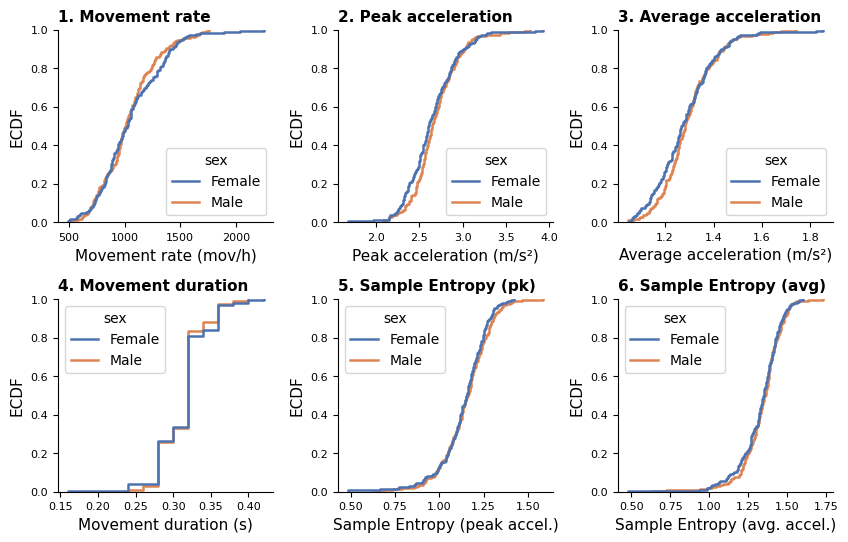

```python
# preparing a 10x6 inch figure with 2 rows and 3 columns of subplots
# hspace and wspace are the height and width spaces between subplots
fig = plt.figure(figsize=(10, 6))
gs = GridSpec(2, 3, figure=fig, hspace=0.4, wspace=0.3)

# We are making `axes` dictionary to map each column name to each subplot axis.
# This way, we can loop through `axes` dictionary later.
keys = kin_df.columns[2:]
axes = {
    keys[0]: fig.add_subplot(gs[0, 0]),
    keys[1]: fig.add_subplot(gs[0, 1]),
    keys[2]: fig.add_subplot(gs[0, 2]),
    keys[3]: fig.add_subplot(gs[1, 0]),
    keys[4]: fig.add_subplot(gs[1, 1]),
    keys[5]: fig.add_subplot(gs[1, 2]),
}

# 1. Prepare titles and xlabels separately
titles = [ "1. Movement rate", "2. Peak acceleration",
"3. Average acceleration", "4. Movement duration",
"5. Sample Entropy (pk)", "6. Sample Entropy (avg)"]

xlabels = ["Movement rate (mov/h)", "Peak acceleration (m/s²)",
"Average acceleration (m/s²)", "Movement duration (s)",
"Sample Entropy (peak accel.)", "Sample Entropy (avg. accel.)"]

# 2. Loop through axes and titles using `zip`
for key, title, xlabel in zip(keys, titles, xlabels):
    ecdf(ax=axes[key], x=key, hue="sex", data=kin_df, xlabel=xlabel, title=title)

# This command will remove the top and the right spines of all subplots
sns.despine(fig=fig)
```

So you see that the you can use a function instead of writing multiple lines that are basically identical, differing only in their parameter values. Using for-loop to iterate over titles to labels is another key point to note.

Of course, this may limit your ability to customize each subplot, since the same *style* will be applied across all of them. For example, if you want to adjust the x-axis limit of subplot 5 only, you'll need to make additional tweaks. Still, this is an effective way to automate your workflow!